# Prediction Assigment

## Data Science Specialization - Practical Machine Learning

## Juan Guillermo López Guzmán

First we have to load the required libraries for build our prediction model

```r
        library(caret)
        library(dplyr)
```

After we download the database into the local work directory we load to R and show the variables like a first approach to our database

```r
        db<-read.csv("pml-training.csv")
        names(db)
```

```
##   [1] "X"                        "user_name"
##   [3] "raw_timestamp_part_1"     "raw_timestamp_part_2"
##   [5] "cvtd_timestamp"           "new_window"
##   [7] "num_window"               "roll_belt"
##   [9] "pitch_belt"               "yaw_belt"
##  [11] "total_accel_belt"         "kurtosis_roll_belt"
##  [13] "kurtosis_picth_belt"      "kurtosis_yaw_belt"
##  [15] "skewness_roll_belt"       "skewness_roll_belt.1"
##  [17] "skewness_yaw_belt"        "max_roll_belt"
##  [19] "max_picth_belt"           "max_yaw_belt"
##  [21] "min_roll_belt"            "min_pitch_belt"
##  [23] "min_yaw_belt"             "amplitude_roll_belt"
##  [25] "amplitude_pitch_belt"     "amplitude_yaw_belt"
##  [27] "var_total_accel_belt"     "avg_roll_belt"
##  [29] "stddev_roll_belt"         "var_roll_belt"
```

[output cut: 65 more lines]

```r
        db<-db[-c(1:8)]
        summary(db)
```

```
##    pitch_belt          yaw_belt       total_accel_belt kurtosis_roll_belt
##  Min.   :-55.8000   Min.   :-180.00   Min.   : 0.00             :19216
##  1st Qu.:  1.7600   1st Qu.: -88.30   1st Qu.: 3.00    #DIV/0!  :   10
##  Median :  5.2800   Median : -13.00   Median :17.00    -1.908453:    2
##  Mean   :  0.3053   Mean   : -11.21   Mean   :11.31    -0.016850:    1
##  3rd Qu.: 14.9000   3rd Qu.:  12.90   3rd Qu.:18.00    -0.021024:    1
##  Max.   : 60.3000   Max.   : 179.00   Max.   :29.00    -0.025513:    1
##                                                        (Other)  :  391
##  kurtosis_picth_belt kurtosis_yaw_belt skewness_roll_belt
##           :19216            :19216              :19216
##  #DIV/0!  :   32     #DIV/0!:  406     #DIV/0!  :    9
##  47.000000:    4                       0.000000 :    4
##  -0.150950:    3                       0.422463 :    2
##  -0.684748:    3                       -0.003095:    1
##  -1.750749:    3                       -0.010002:    1
##  (Other)  :  361                       (Other)  :  389
##  skewness_roll_belt.1 skewness_yaw_belt max_roll_belt     max_picth_belt
##           :19216             :19216     Min.   :-94.300   Min.   : 3.00
##  #DIV/0!  :   32      #DIV/0!:  406     1st Qu.:-88.000   1st Qu.: 5.00
##  0.000000 :    4                        Median : -5.100   Median :18.00
##  -2.156553:    3                        Mean   : -6.667   Mean   :12.92
##  -3.072669:    3                        3rd Qu.: 18.500   3rd Qu.:19.00
##  -6.324555:    3                        Max.   :180.000   Max.   :30.00
##  (Other)  :  361                        NA's   :19216     NA's   :19216
##   max_yaw_belt   min_roll_belt     min_pitch_belt   min_yaw_belt
##         :19216   Min.   :-180.00   Min.   : 0.00          :19216
##  -1.1   :   30   1st Qu.: -88.40   1st Qu.: 3.00   -1.1   :   30
##  -1.4   :   29   Median :  -7.85   Median :16.00   -1.4   :   29
##  -1.2   :   26   Mean   : -10.44   Mean   :10.76   -1.2   :   26
##  -0.9   :   24   3rd Qu.:   9.05   3rd Qu.:17.00   -0.9   :   24
##  -1.3   :   22   Max.   : 173.00   Max.   :23.00   -1.3   :   22
##  (Other):  275   NA's   :19216     NA's   :19216   (Other):  275
##  amplitude_roll_belt amplitude_pitch_belt amplitude_yaw_belt
##  Min.   :  0.000     Min.   : 0.000              :19216
##  1st Qu.:  0.300     1st Qu.: 1.000       #DIV/0!:   10
##  Median :  1.000     Median : 1.000       0.00   :   12
##  Mean   :  3.769     Mean   : 2.167       0.0000 :  384
##  3rd Qu.:  2.083     3rd Qu.: 2.000
##  Max.   :360.000     Max.   :12.000
##  NA's   :19216       NA's   :19216
```

[output cut: 297 more lines]

```
##  Min.   :-446.00   Min.   :-1280.0   Min.   :-896.0   Min.   :-973.0
##  1st Qu.:-182.00   1st Qu.: -616.0   1st Qu.:   2.0   1st Qu.: 191.0
##  Median : -39.00   Median : -378.0   Median : 591.0   Median : 511.0
##  Mean   : -55.29   Mean   : -312.6   Mean   : 380.1   Mean   : 393.6
##  3rd Qu.:  26.00   3rd Qu.:  -73.0   3rd Qu.: 737.0   3rd Qu.: 653.0
##  Max.   : 291.00   Max.   :  672.0   Max.   :1480.0   Max.   :1090.0
##
##  classe
##  A:5580
##  B:3797
##  C:3422
##  D:3216
##  E:3607
##
##
```

There is a lot of variables incompletes so we are identifying them and deleting

```r
        ##using vector to clean database
        vector<-c()
        ##loop to identify the NA variables
        for(i in names(db)){
                if(sum(is.na(db[i]))<19216){
                        vector<-c(vector,i)
                }
        }
        db<-db[vector]
        ##loop to identify the empty variables
        vector<-c()
        for(i in names(db)){
                if(sum(db[i]=="")<19216){
                        vector<-c(vector,i)
                }
        }
        db<-db[vector]
```

Now we obtained a clean database with more usefull predictors thus we can cut the database into the training, testing and validation sets

```r
        inTrain<-createDataPartition(db$classe,p=0.8,list=FALSE)
        training<-db[inTrain,]
        testing<-db[-inTrain,]
        inTrain<-createDataPartition(training$classe,p=0.8,list=FALSE)
        validating<-training[-inTrain,]
        training<-training[inTrain,]
```

In order to pick the best method and predictors we will use cross validation then we have to cut the training set in equaly sized folds for each method and preserve a fold with indepedent data for calculate the error or accuracy

```r
        ##prepare training set for cross validation
        training$group<-rep(1:16,len=length(training$classe))
```

We saw in the database summary four variable subgroups: belt, arm, dumbell and forearm so we are fitting three types of models in the total of variables and each mentioned subgroup

Is important to understand that we can’t use regresion models for this kind of classification models so we choose: random forest, boosting and decission trees like the models to probe

```r
        ##fit random forest models to assigned folds
        train_tmp<-filter(training,group==1)[-53]
        mod1<-train(classe~.,method="rf",prox=TRUE,data=train_tmp)
        train_tmp<-filter(training,group==2)[-53]
        train_tmp<-data.frame(select(train_tmp,contains("_belt")),classe=train_tmp$classe)
        mod2<-train(classe~.,method="rf",prox=TRUE,data=train_tmp)
        train_tmp<-filter(training,group==3)[-53]
        train_tmp<-data.frame(select(train_tmp,contains("_arm")),classe=train_tmp$classe)
        mod3<-train(classe~.,method="rf",prox=TRUE,data=train_tmp)
        train_tmp<-filter(training,group==4)[-53]
        train_tmp<-data.frame(select(train_tmp,contains("_dumbbell")),classe=train_tmp$classe)
        mod4<-train(classe~.,method="rf",prox=TRUE,data=train_tmp)
        train_tmp<-filter(training,group==5)[-53]
        train_tmp<-data.frame(select(train_tmp,contains("_forearm")),classe=train_tmp$classe)
        mod5<-train(classe~.,method="rf",prox=TRUE,data=train_tmp)
        ##fit boosting models to assigned folds
        train_tmp<-filter(training,group==6)[-53]
        mod6<-train(classe~.,method="gbm",data=train_tmp)
        train_tmp<-filter(training,group==7)[-53]
        train_tmp<-data.frame(select(train_tmp,contains("_belt")),classe=train_tmp$classe)
        mod7<-train(classe~.,method="gbm",data=train_tmp)
        train_tmp<-filter(training,group==8)[-53]
        train_tmp<-data.frame(select(train_tmp,contains("_arm")),classe=train_tmp$classe)
        mod8<-train(classe~.,method="gbm",data=train_tmp)
        train_tmp<-filter(training,group==9)[-53]
        train_tmp<-data.frame(select(train_tmp,contains("_dumbbell")),classe=train_tmp$classe)
        mod9<-train(classe~.,method="gbm",data=train_tmp)
        train_tmp<-filter(training,group==10)[-53]
        train_tmp<-data.frame(select(train_tmp,contains("_forearm")),classe=train_tmp$classe)
        mod10<-train(classe~.,method="gbm",data=train_tmp)
        ##fit decission tree models to assigned folds
        train_tmp<-filter(training,group==11)[-53]
        mod11<-train(classe~.,method="rpart",data=train_tmp)
        train_tmp<-filter(training,group==12)[-53]
        train_tmp<-data.frame(select(train_tmp,contains("_belt")),classe=train_tmp$classe)
        mod12<-train(classe~.,method="rpart",data=train_tmp)
        train_tmp<-filter(training,group==13)[-53]
        train_tmp<-data.frame(select(train_tmp,contains("_arm")),classe=train_tmp$classe)
        mod13<-train(classe~.,method="rpart",data=train_tmp)
        train_tmp<-filter(training,group==14)[-53]
        train_tmp<-data.frame(select(train_tmp,contains("_dumbbell")),classe=train_tmp$classe)
        mod14<-train(classe~.,method="rpart",data=train_tmp)
        train_tmp<-filter(training,group==15)[-53]
        train_tmp<-data.frame(select(train_tmp,contains("_forearm")),classe=train_tmp$classe)
        mod15<-train(classe~.,method="rpart",data=train_tmp)
```

Like we said to calculate the out of sample error in each model we are using an indepedent fold and create a matrix with all the predicted values and compare them with the real values

```r
        train_tmp<-filter(training,group==16)[-53]
        pred_matrix<-data.frame(classe=train_tmp$classe,pred1=predict(mod1,train_tmp),pred2=predict(mod2,train_tmp),
                pred3=predict(mod3,train_tmp),pred4=predict(mod4,train_tmp),pred5=predict(mod5,
                train_tmp),pred6=predict(mod6,train_tmp),pred7=predict(mod7,train_tmp),pred8=predict(mod8,train_tmp),
                pred9=predict(mod9,train_tmp),pred10=predict(mod10,train_tmp),pred11=predict(mod11,train_tmp),
                pred12=predict(mod12,train_tmp),pred13=predict(mod13,train_tmp),pred14=predict(mod14,train_tmp),
                pred15=predict(mod15,train_tmp))
```

Afterthat we can observe the behavior of the models in the graph below

[figure not shown]

```r
        pairs(pred_matrix)
```

```r
        acc_vector<-data.frame(
                pred1=sum(diag(table(pred_matrix$pred1,pred_matrix$classe)))/length(pred_matrix$classe),
                pred2=sum(diag(table(pred_matrix$pred2,pred_matrix$classe)))/length(pred_matrix$classe),
                pred3=sum(diag(table(pred_matrix$pred3,pred_matrix$classe)))/length(pred_matrix$classe),
                pred4=sum(diag(table(pred_matrix$pred4,pred_matrix$classe)))/length(pred_matrix$classe),
                pred5=sum(diag(table(pred_matrix$pred5,pred_matrix$classe)))/length(pred_matrix$classe),
                pred6=sum(diag(table(pred_matrix$pred6,pred_matrix$classe)))/length(pred_matrix$classe),
                pred7=sum(diag(table(pred_matrix$pred7,pred_matrix$classe)))/length(pred_matrix$classe),
                pred8=sum(diag(table(pred_matrix$pred8,pred_matrix$classe)))/length(pred_matrix$classe),
                pred9=sum(diag(table(pred_matrix$pred9,pred_matrix$classe)))/length(pred_matrix$classe),
                pred10=sum(diag(table(pred_matrix$pred10,pred_matrix$classe)))/length(pred_matrix$classe),
                pred11=sum(diag(table(pred_matrix$pred11,pred_matrix$classe)))/length(pred_matrix$classe),
                pred12=sum(diag(table(pred_matrix$pred12,pred_matrix$classe)))/length(pred_matrix$classe),
                pred13=sum(diag(table(pred_matrix$pred13,pred_matrix$classe)))/length(pred_matrix$classe),
                pred14=sum(diag(table(pred_matrix$pred14,pred_matrix$classe)))/length(pred_matrix$classe),
                pred15=sum(diag(table(pred_matrix$pred15,pred_matrix$classe)))/length(pred_matrix$classe))
        acc_vector
```

```
##       pred1     pred2     pred3     pred4     pred5     pred6     pred7
## 1 0.9745223 0.7796178 0.5796178 0.7630573 0.6547771 0.8815287 0.7044586
##       pred8    pred9    pred10    pred11    pred12    pred13    pred14
## 1 0.4828025 0.677707 0.5898089 0.5719745 0.3719745 0.3949045 0.3872611
##      pred15
## 1 0.3643312
```

In conclusion, the random forest and boosting models aplied to all the variable have better accuracy with 0.9745223 and 0.8815287 respectively so we will conserve and tune them with the testing set

```r
        mod1<-mod1
        mod2<-mod6
```

Can blended models improve the accuracy? We are answering this question using cross validation. We are spliting the testing set in order to train two blended models using the same methods: random forest and boosting

```r
        testing$group<-rep(1:3,len=length(testing$classe))
        test_tmp<-filter(testing,group==1)[-53]
        pred_matrix<-data.frame(classe=test_tmp$classe,pred1=predict(mod1,test_tmp),pred2=predict(mod2,test_tmp))
        mod3<-train(classe~.,method="rf",prox=TRUE,data=pred_matrix)
        test_tmp<-filter(testing,group==2)[-53]
        pred_matrix<-data.frame(classe=test_tmp$classe,pred1=predict(mod1,test_tmp),pred2=predict(mod2,test_tmp))
        mod4<-train(classe~.,method="gbm",data=pred_matrix)
```

The third fold will be use for run the models and see the blended predictors behavior against the simple predictors:

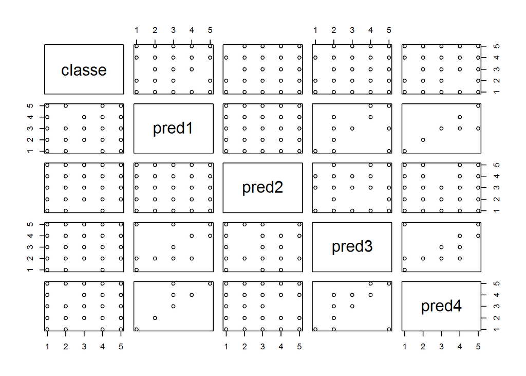

```r
        test_tmp<-filter(testing,group==3)[-53]
        pred_matrix<-data.frame(classe=test_tmp$classe,pred1=predict(mod1,test_tmp),pred2=predict(mod2,test_tmp))
        pred_matrix<-data.frame(pred_matrix,pred3=predict(mod3,pred_matrix),pred4=predict(mod4,pred_matrix))
        pairs(pred_matrix)
```

Aparently the boosting model aplied over the random forest and boosting simple predictors have a large correlation with the real values. We are calculating an accuracy vector to validate this hypothesis

```r
        acc_vector<-data.frame(
                pred1=sum(diag(table(pred_matrix$pred1,pred_matrix$classe)))/length(pred_matrix$classe),
                pred2=sum(diag(table(pred_matrix$pred2,pred_matrix$classe)))/length(pred_matrix$classe),
                pred3=sum(diag(table(pred_matrix$pred3,pred_matrix$classe)))/length(pred_matrix$classe),
                pred4=sum(diag(table(pred_matrix$pred4,pred_matrix$classe)))/length(pred_matrix$classe))
        acc_vector
```

```
##       pred1     pred2     pred3     pred4
## 1 0.9196634 0.8859985 0.9204285 0.9211936
```

The blended model have better performance with a 0.9211936 accuracy so our final model will be apply in the validation set to see calulate out of sample error

```r
        pred_final<-predict(mod4,data.frame(pred1=predict(mod1,validating),pred2=predict(mod2,validating)))
        error<-1-sum(diag(table(pred_final,validating$classe)))/length(validating$classe)
```

Then the out of sample error obtained is the 0.0790564